# Project Python Foundations: FoodHub Data Analysis

### Context

The number of restaurants in New York is increasing day by day. Lots of students and busy professionals rely on those restaurants due to their hectic lifestyles. Online food delivery service is a great option for them. It provides them with good food from their favorite restaurants. A food aggregator company FoodHub offers access to multiple restaurants through a single smartphone app.

The app allows the restaurants to receive a direct online order from a customer. The app assigns a delivery person from the company to pick up the order after it is confirmed by the restaurant. The delivery person then uses the map to reach the restaurant and waits for the food package. Once the food package is handed over to the delivery person, he/she confirms the pick-up in the app and travels to the customer's location to deliver the food. The delivery person confirms the drop-off in the app after delivering the food package to the customer. The customer can rate the order in the app. The food aggregator earns money by collecting a fixed margin of the delivery order from the restaurants.

### Objective

The food aggregator company has stored the data of the different orders made by the registered customers in their online portal. They want to analyze the data to get a fair idea about the demand of different restaurants which will help them in enhancing their customer experience. Suppose you are hired as a Data Scientist in this company and the Data Science team has shared some of the key questions that need to be answered. Perform the data analysis to find answers to these questions that will help the company to improve the business.

### Data Description

The data contains the different data related to a food order. The detailed data dictionary is given below.

### Data Dictionary

- order_id: Unique ID of the order
- customer_id: ID of the customer who ordered the food
- restaurant_name: Name of the restaurant
- cuisine_type: Cuisine ordered by the customer
- cost_of_the_order: Cost of the order
- day_of_the_week: Indicates whether the order is placed on a weekday or weekend (The weekday is from Monday to Friday and the weekend is Saturday and Sunday)
- rating: Rating given by the customer out of 5
- food_preparation_time: Time (in minutes) taken by the restaurant to prepare the food. This is calculated by taking the difference between the timestamps of the restaurant's order confirmation and the delivery person's pick-up confirmation.
- delivery_time: Time (in minutes) taken by the delivery person to deliver the food package. This is calculated by taking the difference between the timestamps of the delivery person's pick-up confirmation and drop-off information

```python
# Installing the libraries with the specified version.
#!pip install numpy==1.25.2 pandas==1.5.3 matplotlib==3.7.1 seaborn==0.13.1 -q --user
```

### Let us start by importing the required libraries

**Note**: *After running the above cell, kindly restart the notebook kernel and run all cells sequentially from the start again.*

```python
# import libraries for data manipulation
import numpy as np
import pandas as pd

# import libraries for data visualization
import matplotlib.pyplot as plt
import seaborn as sns
```

### Understanding the structure of the data

```python
# uncomment and run the following lines for Google Colab
#from google.colab import drive
#drive.mount('/content/drive')
```

```python
# Write your code here to read the data
df = pd.read_csv("C:\\Users\\mardin\\Downloads\\foodhub_order.csv")
```

```python
# Write your code here to view the first 5 rows
df.head()
```

|  | order_id | customer_id | restaurant_name | cuisine_type | cost_of_the_order | day_of_the_week | rating | food_preparation_time | delivery_time |
| --- | --- | --- | --- | --- | --- | --- | --- | --- | --- |
| 0 | 1477147 | 337525 | Hangawi | Korean | 30.75 | Weekend | Not given | 25 | 20 |
| 1 | 1477685 | 358141 | Blue Ribbon Sushi Izakaya | Japanese | 12.08 | Weekend | Not given | 25 | 23 |
| 2 | 1477070 | 66393 | Cafe Habana | Mexican | 12.23 | Weekday | 5 | 23 | 28 |
| 3 | 1477334 | 106968 | Blue Ribbon Fried Chicken | American | 29.20 | Weekend | 3 | 25 | 15 |
| 4 | 1478249 | 76942 | Dirty Bird to Go | American | 11.59 | Weekday | 4 | 25 | 24 |

### **Question 1:** How many rows and columns are present in the data? [0.5 mark]

```python
# Shape of the dataset
df.shape
```

```
(1898, 9)
```

#### Observations:

There are 1898 rows and 9 columns in the dataset

### **Question 2:** What are the datatypes of the different columns in the dataset? (The info() function can be used) [0.5 mark]

```python
# Checking the datatypes of the different columns
df.info()
```

```
<class 'pandas.core.frame.DataFrame'>
RangeIndex: 1898 entries, 0 to 1897
Data columns (total 9 columns):
 #   Column                 Non-Null Count  Dtype
---  ------                 --------------  -----
 0   order_id               1898 non-null   int64
 1   customer_id            1898 non-null   int64
 2   restaurant_name        1898 non-null   object
 3   cuisine_type           1898 non-null   object
 4   cost_of_the_order      1898 non-null   float64
 5   day_of_the_week        1898 non-null   object
 6   rating                 1898 non-null   object
 7   food_preparation_time  1898 non-null   int64
 8   delivery_time          1898 non-null   int64
dtypes: float64(1), int64(4), object(4)
memory usage: 133.6+ KB
```

#### Observations:

1. There are a total of 9 columns in the dataset. Of these columns, 4 are integers, 4 are strings(known as "object") and one is a float (cost of the order)
2. order_id is unique in that it cannot be repeated. Integer datatype.
3. rating is usually numerical but the datatype is indicated as object because some customers did not give a rating. This was entered as "Not given". These should be replaced by Nan.

### **Question 3:** Are there any missing values in the data? If yes, treat them using an appropriate method. [1 mark]

```python
# Checking missing values
df.isnull().sum()
df["rating"] = df["rating"].replace("Not given", np.nan)
df["rating"] = df["rating"].astype(float)

df.isnull().sum()
```

```
order_id                   0
customer_id                0
restaurant_name            0
cuisine_type               0
cost_of_the_order          0
day_of_the_week            0
rating                   736
food_preparation_time      0
delivery_time              0
dtype: int64
```

#### Observations:

- It would seem that the dataset is clean as there are no missing values at first. Some customers did not rate their orders but it is only indicated as "Not given". These are missing values and therefore they need to be shown accordingly by running df["rating"] = df["rating"].replace("Not given", np.nan). Then we ought to change the datatype in rating from object to float so that we can get the statistical summary of the ratings.
- We can now observe that 736 orders were not given a rating. In this case, for an unbiased analysis it is best to leave them as NaN.

```python
df.info()
```

```
<class 'pandas.core.frame.DataFrame'>
RangeIndex: 1898 entries, 0 to 1897
Data columns (total 9 columns):
 #   Column                 Non-Null Count  Dtype
---  ------                 --------------  -----
 0   order_id               1898 non-null   int64
 1   customer_id            1898 non-null   int64
 2   restaurant_name        1898 non-null   object
 3   cuisine_type           1898 non-null   object
 4   cost_of_the_order      1898 non-null   float64
 5   day_of_the_week        1898 non-null   object
 6   rating                 1162 non-null   float64
 7   food_preparation_time  1898 non-null   int64
 8   delivery_time          1898 non-null   int64
dtypes: float64(2), int64(4), object(3)
memory usage: 133.6+ KB
```

### **Question 4:** Check the statistical summary of the data. What is the minimum, average, and maximum time it takes for food to be prepared once an order is placed? [2 marks]

```python
# Checking the statistical summary of the data
df.describe().T
```

|  | count | mean | std | min | 25% | 50% | 75% | max |
| --- | --- | --- | --- | --- | --- | --- | --- | --- |
| order_id | 1898.0 | 1.477496e+06 | 548.049724 | 1476547.00 | 1477021.25 | 1477495.50 | 1.477970e+06 | 1478444.00 |
| customer_id | 1898.0 | 1.711685e+05 | 113698.139743 | 1311.00 | 77787.75 | 128600.00 | 2.705250e+05 | 405334.00 |
| cost_of_the_order | 1898.0 | 1.649885e+01 | 7.483812 | 4.47 | 12.08 | 14.14 | 2.229750e+01 | 35.41 |
| rating | 1162.0 | 4.344234e+00 | 0.741478 | 3.00 | 4.00 | 5.00 | 5.000000e+00 | 5.00 |
| food_preparation_time | 1898.0 | 2.737197e+01 | 4.632481 | 20.00 | 23.00 | 27.00 | 3.100000e+01 | 35.00 |
| delivery_time | 1898.0 | 2.416175e+01 | 4.972637 | 15.00 | 20.00 | 25.00 | 2.800000e+01 | 33.00 |

#### Observations:

##### Food_Preparation_Time(minutes):

- Minimum Time = 20 minutes
- Average Time = 27.37 minutes
- Maximum Time = 35 minutes

### **Question 5:** How many orders are not rated? [1 mark]

```python
# Checking the number of orders whose ratings were not given
df["rating"].isna().sum()
```

```
736
```

#### Observations:

736 orders were not rated.

### Exploratory Data Analysis (EDA)

### **Question 6:** Explore all the variables and provide observations on their distributions. (Generally, histograms, boxplots, countplots, etc. are used for univariate exploration.) [9 marks]

#### Categorical Variables

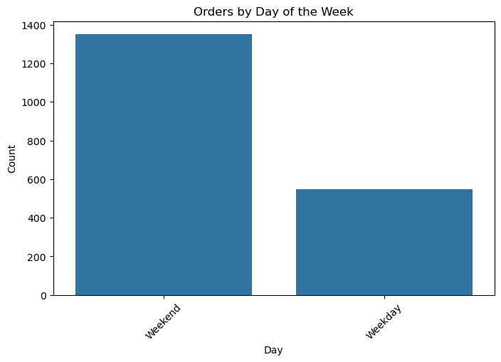

```python
# Observing the number of orders by weekday or weekend
plt.figure(figsize=(8, 5))
sns.countplot(data=df, x="day_of_the_week")
plt.title("Orders by Day of the Week")
plt.xlabel("Day")
plt.ylabel("Count")
plt.xticks(rotation=45)
plt.show();
```

- *From this graph, it is observed that most orders were made on weekends than weekdays.*

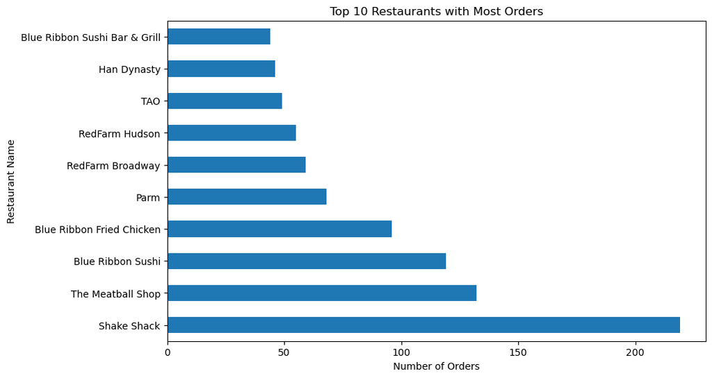

```python
#Top 10 restaurants with the most orders
plt.figure(figsize=(10, 6))
df['restaurant_name'].value_counts().nlargest(10).plot(kind='barh')  # Top 10
plt.xlabel("Number of Orders")
plt.ylabel("Restaurant Name")
plt.title("Top 10 Restaurants with Most Orders")
plt.show()
```

- It made sense to only show the top 10 restaurants with the most orders, as showing all the restaurants would have congested the graph, making it aesthetically unpleasant.
- It is observed that the restaurant with the most number of orders is Shake Shack with over 200 orders.

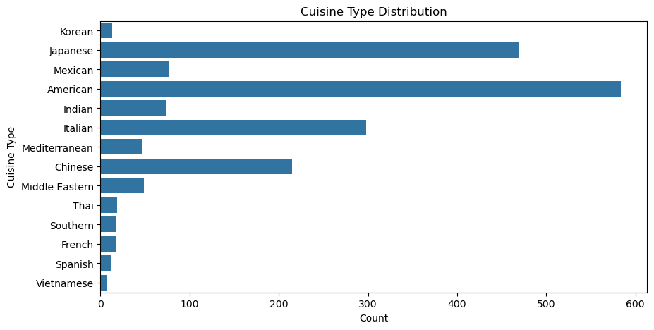

```python
# Observing Cuisine types and their distribution
plt.figure(figsize=(10, 5))
sns.countplot(data=df, y="cuisine_type")
plt.title("Cuisine Type Distribution")
plt.xlabel("Count")
plt.ylabel("Cuisine Type")
plt.show();
```

- From this graph, we can say that American cuisine is the most popular, followed by Japanese. The least popular cuisine is Vietnamese.

#### Numerical Variables

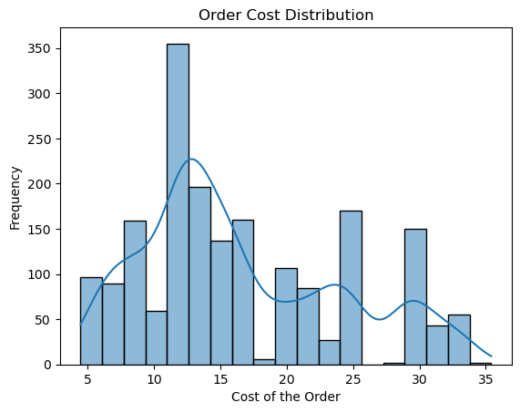

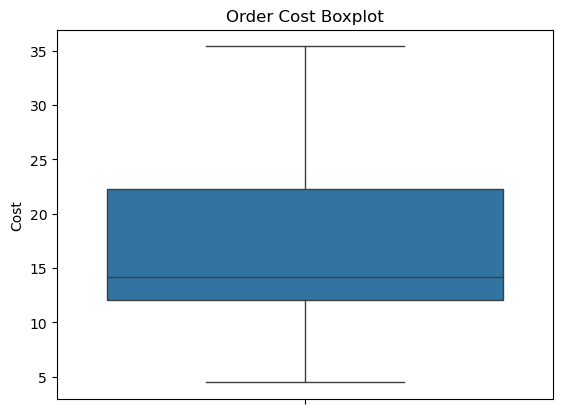

```python
# Order cost distribution
sns.histplot(df["cost_of_the_order"], kde=True)
plt.title("Order Cost Distribution")
plt.xlabel("Cost of the Order")
plt.ylabel("Frequency")
plt.show();

#Boxplot
sns.boxplot(data = df, y = "cost_of_the_order")
plt.title("Order Cost Boxplot")
plt.ylabel("Cost")
plt.show();
```

- It is observed that the order cost distribution follows a right-skewed distribution with more customers ordering relatively cheaper meals.
- The boxplot also shows that the median cost of orders was slightly below 15 dollars, the minimum order being about 5 dollars and the maximum being around 35 dollars. No outliers were observed and therefore it can be said that no extremely expensive orders were made.

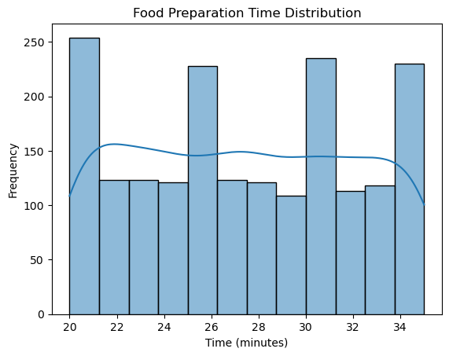

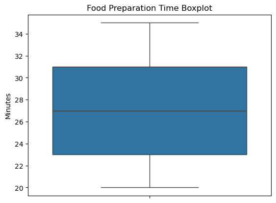

```python
#Food Prep Time Distribution
sns.histplot(data = df, x = "food_preparation_time", kde=True)
plt.title("Food Preparation Time Distribution")
plt.xlabel("Time (minutes)")
plt.ylabel("Frequency")
plt.show()

#Boxplot
sns.boxplot(data = df, y = "food_preparation_time")
plt.title("Food Preparation Time Boxplot")
plt.ylabel("Minutes")
plt.show()
```

- The time spent on food preparation is uniformly distributed. This means that all food preparation takes place at the same frequency. The median is about 27 minutes. The least time spent was 20 minutes and the most time spent was about 35 minutes.
- There are no extreme outliers in either direction.

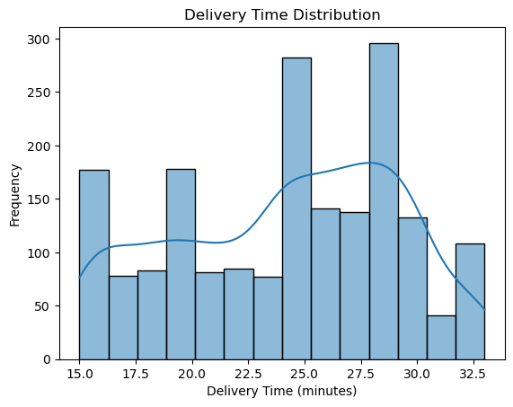

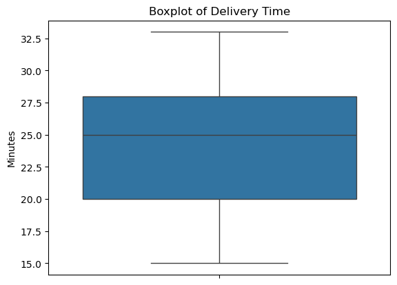

```python
# Delivery Time Distribution
sns.histplot(data = df, x = "delivery_time", kde=True)
plt.title("Delivery Time Distribution")
plt.xlabel("Delivery Time (minutes)")
plt.ylabel("Frequency")
plt.show()

sns.boxplot(data = df, y = "delivery_time")
plt.title("Boxplot of Delivery Time")
plt.ylabel("Minutes")
plt.show()
```

- The histogram suggests a left-skewed distribution. The boxplot also suggests a left-skewed distribution as the median is closer to the third quartile than the first. But the minimum and maximum values are spread out almost evenly.
- This means that most orders take time to be delivered however some orders are prepared fast.
- No extreme outliers were observed in either direction.

### **Question 7**: Which are the top 5 restaurants in terms of the number of orders received? [1 mark]

```python
# Output the top 5 restaurants in terms of the number of orders received
top_restaurants = df["restaurant_name"].value_counts()
top_restaurants.head()
```

```
restaurant_name
Shake Shack                  219
The Meatball Shop            132
Blue Ribbon Sushi            119
Blue Ribbon Fried Chicken     96
Parm                          68
Name: count, dtype: int64
```

#### Observations:

The top 5 restaurants with their respective orders are as follows:

- Shake Shack with 219 orders received
- The Meatball shop with 132 orders received
- Blue Ribbon Sushi with 119 orders received
- Blue Ribbon Fried Chicken with 96 orders received
- Parm with 68 orders received

### **Question 8**: Which is the most popular cuisine on weekends? [1 mark]

```python
# Observing the most popular cuisine on weekends
weekend_orders = df[(df["day_of_the_week"] == "Weekend")]
weekend_orders["cuisine_type"].value_counts().head(1) # Outputs only the first cuisine type
```

```
cuisine_type
American    415
Name: count, dtype: int64
```

#### Observations:

- American cuisine is the most popular on weekends with 415 orders

### **Question 9**: What percentage of the orders cost more than 20 dollars? [2 marks]

```python
# Calculating percentage of orders that cost more than $20
orders_above_20 = df[df["cost_of_the_order"] > 20].shape[0] #shape[0] outputs the number of rows only, no columns
total_orders = df.shape[0]
percentage_over_20 = (orders_above_20 / total_orders) * 100
print(percentage_over_20)
```

```
29.24130663856691
```

#### Observations:

- 29.24% of orders cost more than 20 dollars.

### **Question 10**: What is the mean order delivery time? [1 mark]

```python
# Calculating mean order delivery time
df["delivery_time"].mean()
```

```
24.161749209694417
```

#### Observations:

- The mean order delivery time is 24 minutes and 10 seconds.

### **Question 11:** The company has decided to give 20% discount vouchers to the top 3 most frequent customers. Find the IDs of these customers and the number of orders they placed. [1 mark]

```python
# Finding the top 3 most frequent customers
top_customers = df["customer_id"].value_counts()
top_customers.head(3)
```

```
customer_id
52832    13
47440    10
83287     9
Name: count, dtype: int64
```

#### Observations:

##### Top 3 customers by customer_id:

1. cust_id 52832 - 13 total orders
2. cust_id 47440 - 10 total orders
3. cust_id 83287 - 9 total orders

### **Question 12**: Perform a multivariate analysis to explore relationships between the important variables in the dataset. (It is a good idea to explore relations between numerical variables as well as relations between numerical and categorical variables) [10 marks]

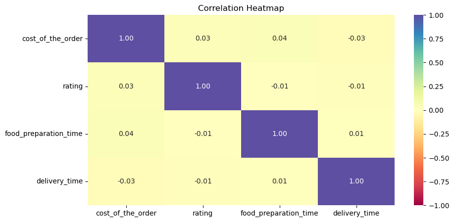

```python
# Correlation heatmap between numerical variables
num_var = ["cost_of_the_order","rating","food_preparation_time","delivery_time"]
corr = df[num_var].corr()

plt.figure(figsize=(10, 5))
sns.heatmap(corr, annot=True, vmin = -1, vmax = 1, cmap = "Spectral", fmt = ".2f")
plt.title("Correlation Heatmap")
plt.show()
```

- It is observed that there is really not much correlation between the numerical variables and that they do not really have much significant impacts on each other.
- Things like the order cost or the delivery time have no effect on the rating.

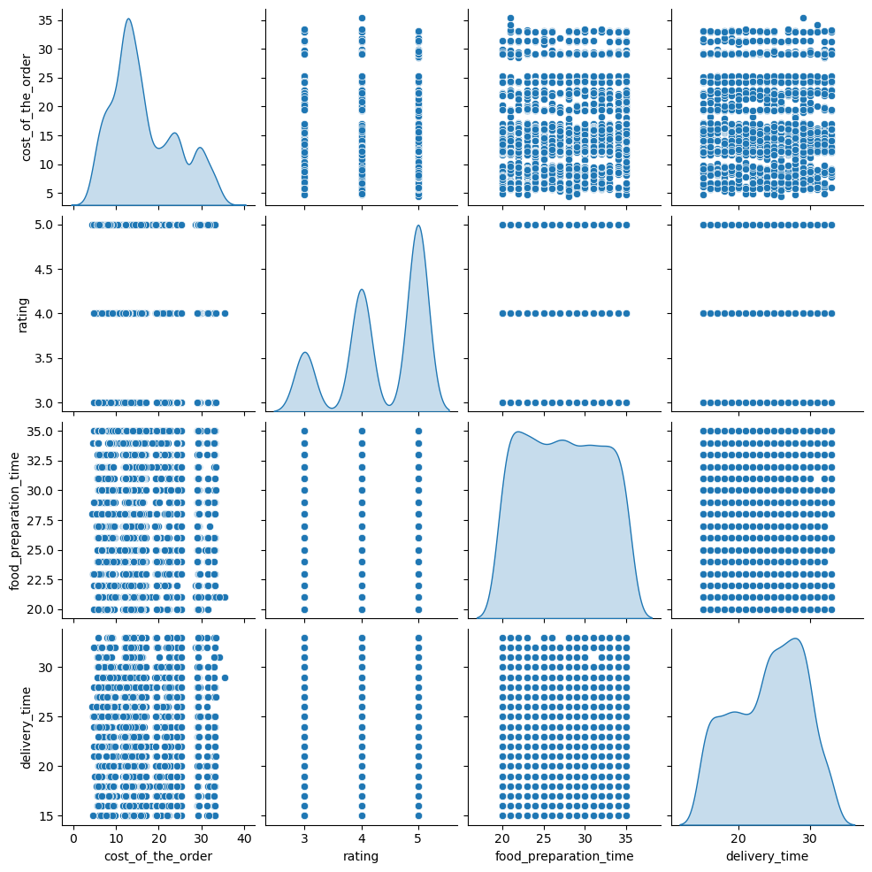

```python
# Pairplot to show relationship between numerical variables
sns.pairplot(data=df[num_var], diag_kind="kde")
plt.show()
```

- It is observed that we get the same insights as the heatmap. There does not seem to be any correlation between the numerical variables.

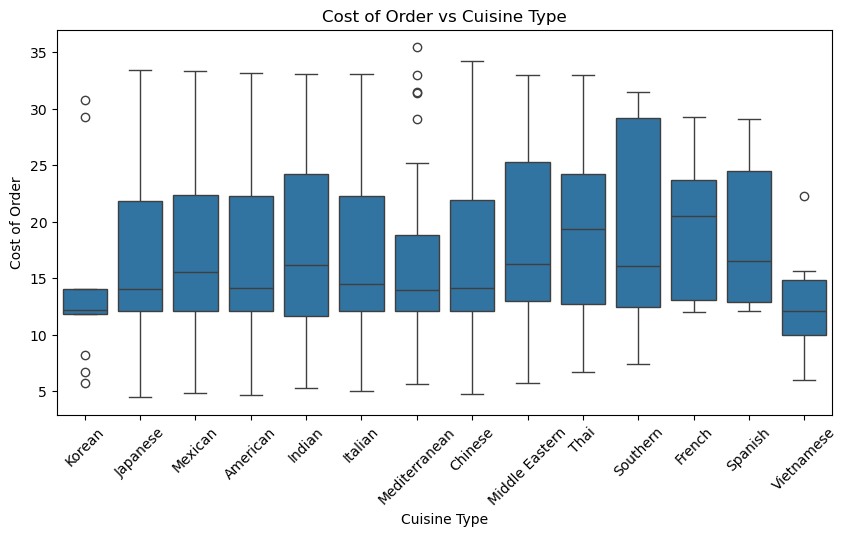

```python
# Plotting Cost of Order against Cuisine Type
plt.figure(figsize=(10, 5))
sns.boxplot(data = df, x = "cuisine_type", y = "cost_of_the_order")
plt.xticks(rotation=45)
plt.title("Cost of Order vs Cuisine Type")
plt.xlabel("Cuisine Type")
plt.ylabel("Cost of Order")
plt.show()
```

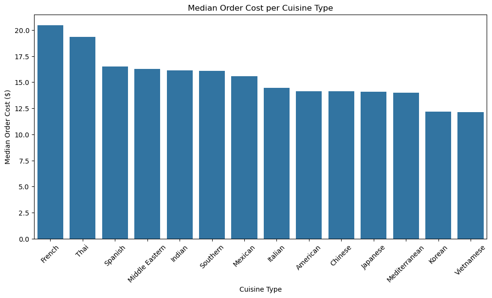

```python
median_cost_per_cuisine = df.groupby("cuisine_type")["cost_of_the_order"].median().reset_index()

# Sorting by median cost for better visualization
median_cost_per_cuisine = median_cost_per_cuisine.sort_values(by="cost_of_the_order", ascending=False)

plt.figure(figsize=(12,6))
sns.barplot(data = median_cost_per_cuisine, x = "cuisine_type", y = "cost_of_the_order")
plt.xticks(rotation=45)
plt.xlabel("Cuisine Type")
plt.ylabel("Median Order Cost ($)")
plt.title("Median Order Cost per Cuisine Type")
plt.show()
```

- The cost of orders for Korean cuisine is concentrated within a narrow range, There are a few outliers, suggesting that while most orders are priced similarly, some are significantly more expensive or cheaper. The absence of whiskers implies that the majority of the data falls within the interquartile range, with only extreme values lying outside.
- French cuisine has the highest median cost.
- Vietnamese cuisine has the lowest median cost.
- Mediterranean cuisine has the highest outlier while having one of the lowest median prices.

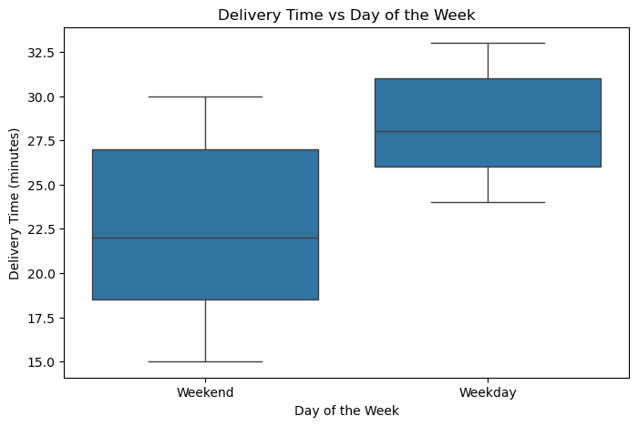

```python
# Plotting Delivery Time against Day of the week
plt.figure(figsize=(8, 5))
sns.boxplot(data = df, x = "day_of_the_week", y = "delivery_time")
plt.title("Delivery Time vs Day of the Week")
plt.xlabel("Day of the Week")
plt.ylabel("Delivery Time (minutes)")
plt.show()
```

It is observed that delivery times take longer on weekdays compared to weekends.

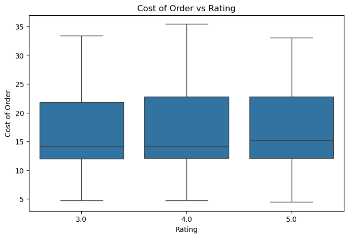

```python
# Plotting Cost of Order against Rating
plt.figure(figsize=(8, 5))
sns.boxplot(data =df, x = "rating", y = "cost_of_the_order")
plt.xlabel("Rating")
plt.ylabel("Cost of Order")
plt.title("Cost of Order vs Rating")
plt.show()
```

- It is observed that orders that had a median rating of 5 were slightly more expensive than orders with a rating of 3 and 4.

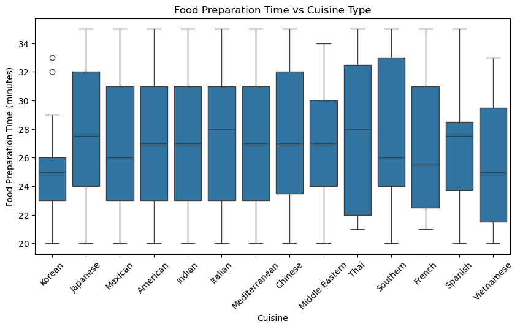

```python
# Plotting Food Prep Time against Cuisine Type
plt.figure(figsize=(10, 5))
sns.boxplot(data =df, x = "cuisine_type", y = "food_preparation_time")
plt.xlabel("Cuisine")
plt.ylabel("Food Preparation Time (minutes)")
plt.xticks(rotation = 45)
plt.title("Food Preparation Time vs Cuisine Type")
plt.show()
```

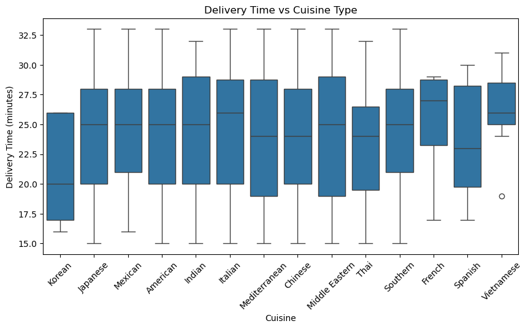

```python
# Plotting Delivery Time against Cuisine Type
plt.figure(figsize=(10, 5))
sns.boxplot(data =df, x = "cuisine_type", y = "delivery_time")
plt.xlabel("Cuisine")
plt.ylabel("Delivery Time (minutes)")
plt.xticks(rotation = 45)
plt.title("Delivery Time vs Cuisine Type")
plt.show()
```

- French cuisine has the highest median delivery time, whereas Korean cuisine has the lowest median delivery time.
- Low presence of outliers, only Vietnamese cuisine has a rapid delivery time compared to what is the norm.

### **Question 13:** The company wants to provide a promotional offer in the advertisement of the restaurants. The condition to get the offer is that the restaurants must have a rating count of more than 50 and the average rating should be greater than 4. Find the restaurants fulfilling the criteria to get the promotional offer. [3 marks]

```python
# Dropping the missing values in the "rating" column
df_filtered = df.dropna(subset=['rating'])

# Grouping by the restaurant and calculating count & mean of ratings
restaurant_ratings = df_filtered.groupby("restaurant_name")["rating"].agg(["count", "mean"])
eligible_restaurants = restaurant_ratings[(restaurant_ratings["count"] > 50) & (restaurant_ratings["mean"] > 4)]
print(eligible_restaurants)
```

```
                           count      mean
restaurant_name
Blue Ribbon Fried Chicken     64  4.328125
Blue Ribbon Sushi             73  4.219178
Shake Shack                  133  4.278195
The Meatball Shop             84  4.511905
```

#### Observations:

Only 4 restaurants fit the criteria aforementioned and are therefore eligible for a promotional offer in their advertisemnets. These are:

- *Blue Ribbon Fried Chicken*
- *Blue Ribbon Sushi*
- *Shake Shack*
- *The Meatball Shop*

### **Question 14:** The company charges the restaurant 25% on the orders having cost greater than 20 dollars and 15% on the orders having cost greater than 5 dollars. Find the net revenue generated by the company across all orders. [3 marks]

```python
# Defining a function to apply commission logic
def calculate_commission(cost):
    if cost > 20:
        return cost * 0.25
    elif cost > 5:
        return cost * 0.15
    else:
        return 0

# Creating a new column and applying the function
df["commission"] = df["cost_of_the_order"].apply(calculate_commission)

net_revenue = df["commission"].sum()
print(net_revenue)
```

```
6166.303
```

#### Observations:

- *The company's net revenue across all orders is $6,166.30*

### **Question 15:** The company wants to analyze the total time required to deliver the food. What percentage of orders take more than 60 minutes to get delivered from the time the order is placed? (The food has to be prepared and then delivered.) [2 marks]

```python
df["total_delivery_time"] = df["food_preparation_time"] + df["delivery_time"]

# Counting orders that take more than 60 minutes
orders_above_60 = df[df["total_delivery_time"] > 60].shape[0]
total_orders = df.shape[0]

percentage_above_60 = (orders_above_60 / total_orders) * 100

print(percentage_above_60)
```

```
10.537407797681771
```

#### Observations:

- It is observed that 10.54% of orders take more than 60 minutes to get delivered from the time the order is placed.

### **Question 16:** The company wants to analyze the delivery time of the orders on weekdays and weekends. How does the mean delivery time vary during weekdays and weekends? [2 marks]

```python
# Calculate mean delivery time for weekdays and weekends
mean_delivery_time = df.groupby("day_of_the_week")["delivery_time"].mean()
print(mean_delivery_time)
```

```
day_of_the_week
Weekday    28.340037
Weekend    22.470022
Name: delivery_time, dtype: float64
```

### Recommendations:

- Optimize delivery efficiency on weekdays by better route optimization or extra delivery personnel.
- A lot of orders (736) which is about 39% of the total orders were not rated. Sending a follow-up notification asking for a rating after order completion or offering some form of incentives for providing feedback would encourage more customer ratings and provide better insights.
- 10.54% of orders take 60 or more minutes to be delivered. By prioritizing high-cost orders or offering fast-delivery options at an extra cost, this can be mitigated.
- Some cuisines take longer to be prepared and delivered. Restaurants could pre-plan items that are in high demand. This would improve prep time.
- Consider incentivizing restaurants to offer bundle deals to increase order value. Moreover, test different commission rates based on cuisine type as well as order volume.